# GEDI ratio cutoff analysis

#### Supervised Gaussian mixture model testing to test annotated GEDI ratios and verify accuracy of prediction

```r
library(mclust)
annotated<-read.csv("/Users/mingyoungshin/Dropbox (Gladstone)/GB-JL-1189-Jeremy-GEDI/Curation_and_GEDI.csv")

#set random seed
set.seed(123)

#take 2/3 of the data as training data
train <- sample(1:nrow(annotated), size = round(nrow(annotated)*2/3), replace = FALSE)
annotated.train <- annotated[train,'GEDIratio']

#take the mean of the votes as the consensus annotation
Class.train <- annotated[train,c("Curator1_Accurate","Curator2_Accurate","Curator3_Accurate","Curator4_Accurate")]
Class.train[is.na(Class.train)]=0.5
Class.train=round(rowMeans(Class.train))

#define the test data
annotated.test <- annotated[-train,'GEDIratio']

#retrieve the annotation of the test data
Class.test <- annotated[-train,c("Curator1_Accurate","Curator2_Accurate","Curator3_Accurate","Curator4_Accurate")]
Class.test=round(rowMeans(Class.test))

#train the model using the train data
mod1 <- MclustDA(annotated.train, as.vector((Class.train)), modelType = "EDDA")

#perform cross validation
cv <- cvMclustDA(mod1)
```

##### Prediction error in supervised Mclust Gaussian mixed model based on annotated data

```r
#retrieve the prediction error
unlist(cv[c('error')])
```

```
##     error
## 0.2670972
```

#### Define outliers corresponding to dead cells using the Hampel filter and Rosner’s test

##### MN1 GEDI ratio distribution and estimated dead cell cutoff

```r
library(EnvStats)
library(DescTools)
MN1<-read.csv("TimelapseDataset1_MNs.csv")


options(warn=-1)
upper_bound <- median(sqrt(MN1$GEDIratio)) + 3 * mad(sqrt(MN1$GEDIratio))
upper_bound
```

```
## [1] 0.1245839
```

```r
hist(sqrt(MN1$GEDIratio),breaks=1000, main=NULL)
#abline(v=upper_bound, col="blue")

outlierC=sum(sqrt(MN1$GEDIratio)>upper_bound)
outlierC
```

```
## [1] 2485
```

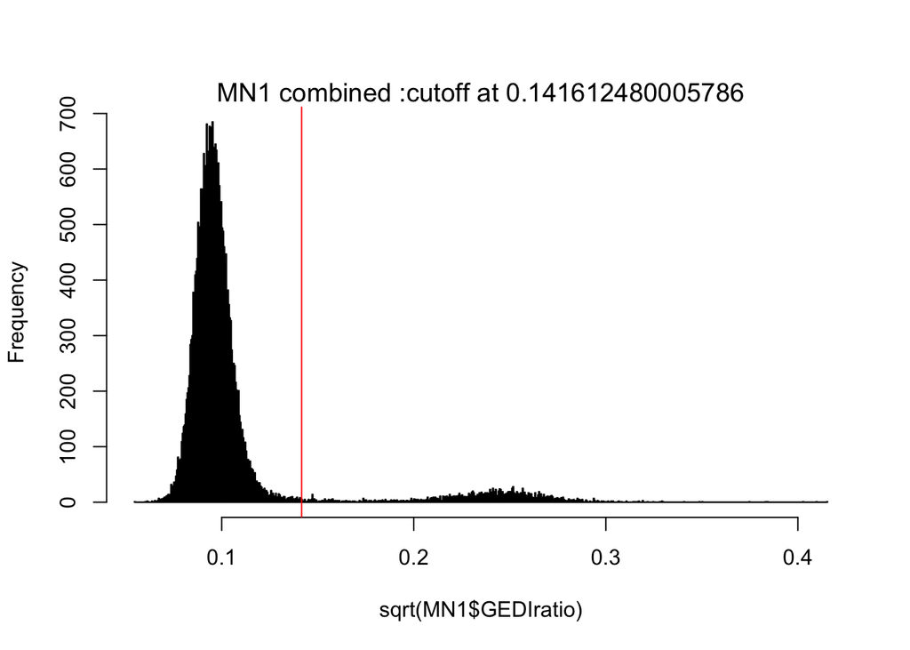

```r
test <- rosnerTest(sqrt(MN1$GEDIratio),
                   k = outlierC)

  outliers=test$all.stats$Value[test$all.stats$Outlier]
  cutoff=min( outliers[which(outliers>median(sqrt(MN1$GEDIratio)))] )


abline(v=cutoff,col="red")

mtext(paste0("MN1 combined :cutoff at ",cutoff),cex=1.2)
```

##### MN1 GEDI ratio distribution and estimated dead cell cutoff per time point

```
## [1] 1
```

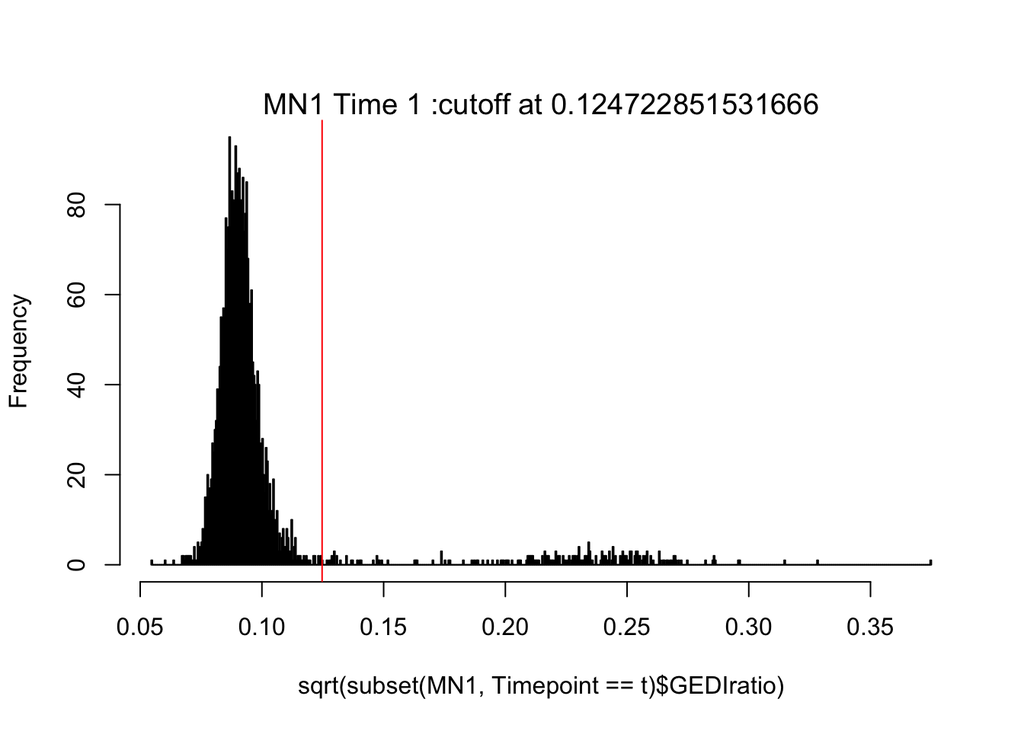

```
## [1] 2
```

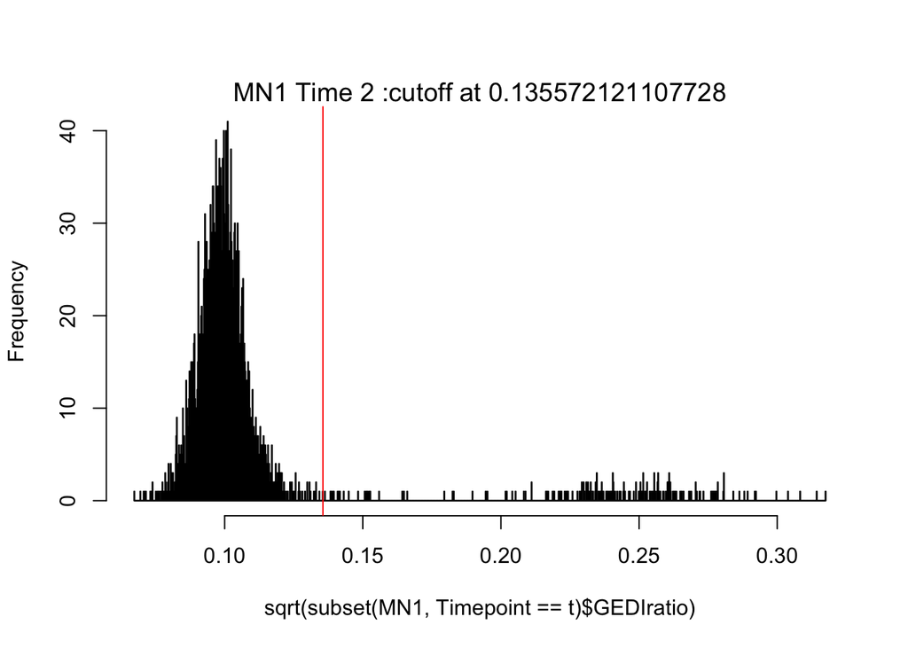

```
## [1] 3
```

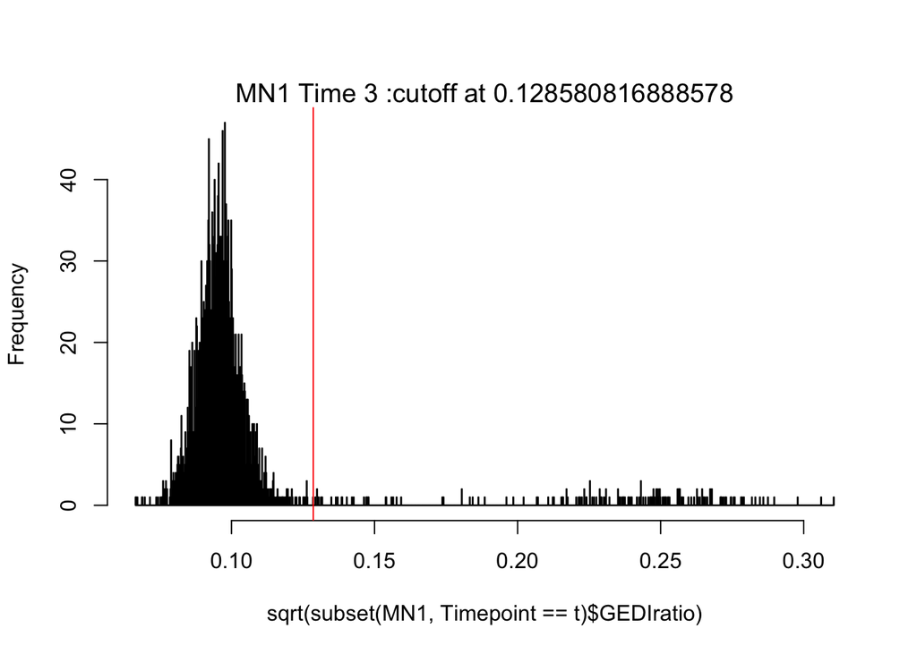

```
## [1] 4
```

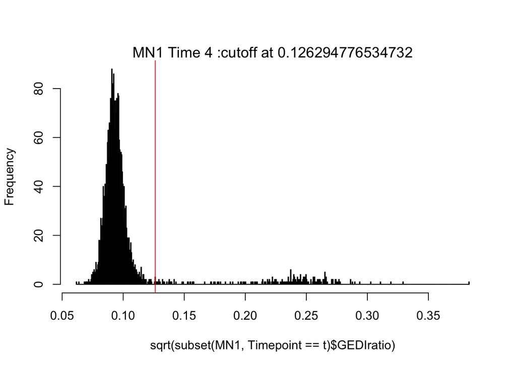

```
## [1] 5
```

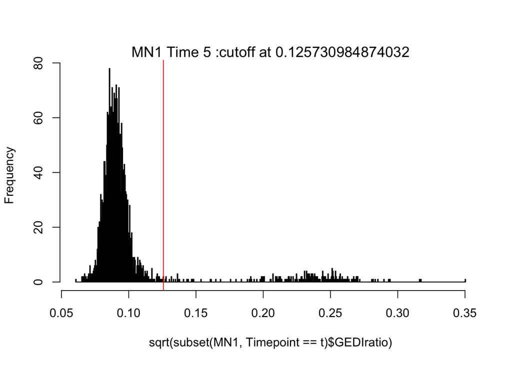

```
## [1] 6
```

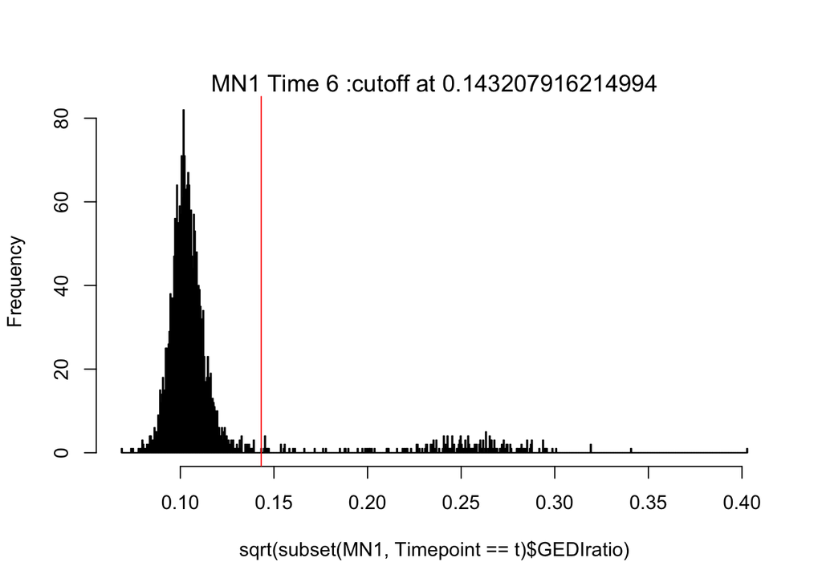

```
## [1] 7
```

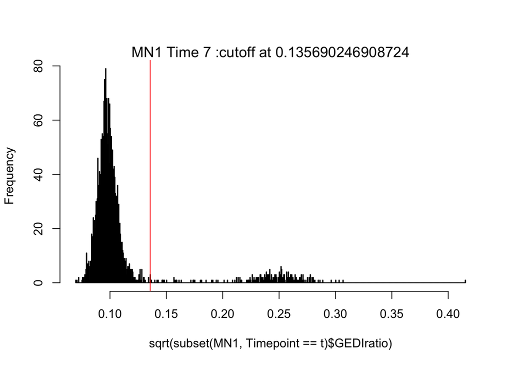

```
## [1] 8
```

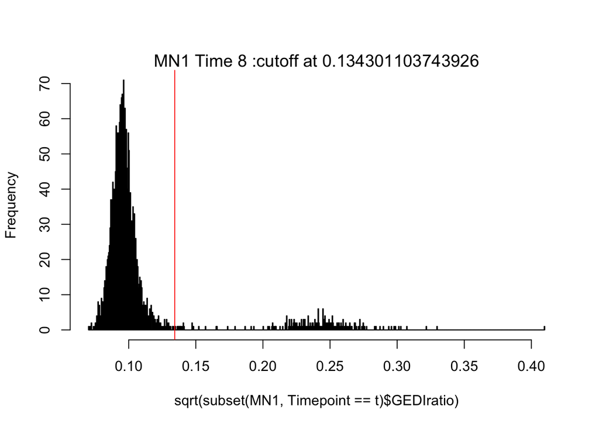

```
## [1] 9
```

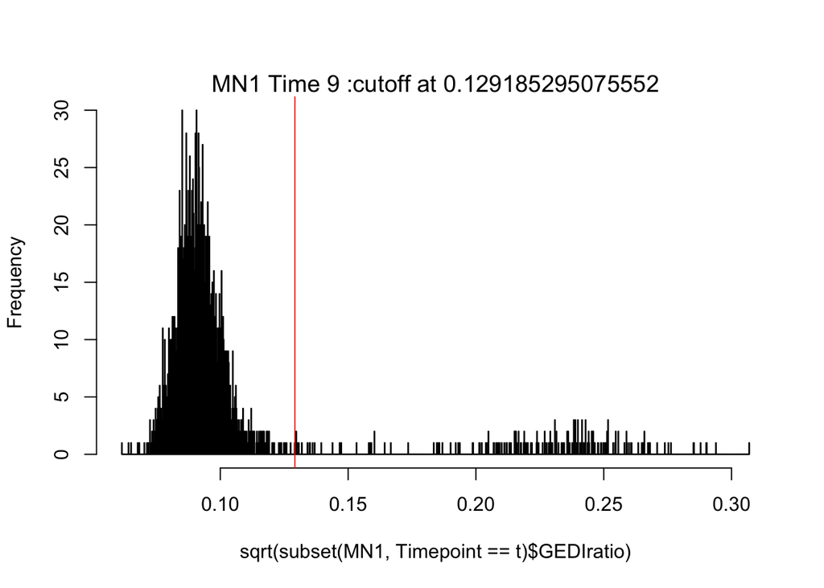

```
## [1] 10
```

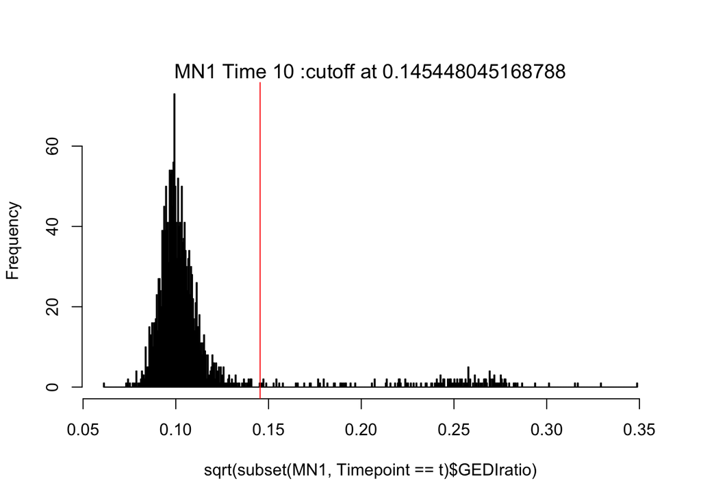

```r
for(t in 1:max(as.numeric(MN1$Timepoint))){

  options(warn=-1)

  par(new=FALSE)
  print(t)
  upper_bound <- median(sqrt(subset(MN1,Timepoint==t)$GEDIratio)) + 3 * mad(sqrt(subset(MN1,Timepoint==t)$GEDIratio))
  upper_bound

  hist(sqrt(subset(MN1,Timepoint==t)$GEDIratio),breaks=1000,main=NULL)
#  abline(v=upper_bound, col="blue")

  outlierC=sum(sqrt(subset(MN1,Timepoint==t)$GEDIratio)>upper_bound)
  outlierC

  test <- rosnerTest(sqrt(subset(MN1,Timepoint==t)$GEDIratio),
                     k = outlierC)
  outliers=test$all.stats$Value[test$all.stats$Outlier]
  cutoff=min( outliers[which(outliers>median(sqrt(subset(MN1,Timepoint==t)$GEDIratio)))] )


  abline(v=cutoff,col="red")
  mtext(paste0("MN1 Time ",t," :cutoff at ",cutoff),cex=1.2)

}
```

##### MN2 GEDI ratio distribution and estimated dead cell cutoff

```r
options(warn=-1)

MN2<-read.csv("TimelapseDataset2_MNs.csv")

library(EnvStats)
library(DescTools)
### Find Hampel filter: outliers are the values outside the interval the median plus 3 median absolute deviations
upper_bound <- median(sqrt(MN2$GEDIratio)) + 3 * mad(sqrt(MN2$GEDIratio))
upper_bound
```

```
## [1] 0.1515096
```

```r
hist(sqrt(MN2$GEDIratio),breaks=1000,main=NULL)
#abline(v=upper_bound, col="blue")

### the number of estimated outliers
outlierC=sum(sqrt(MN2$GEDIratio)>upper_bound)
outlierC
```

```
## [1] 2953
```

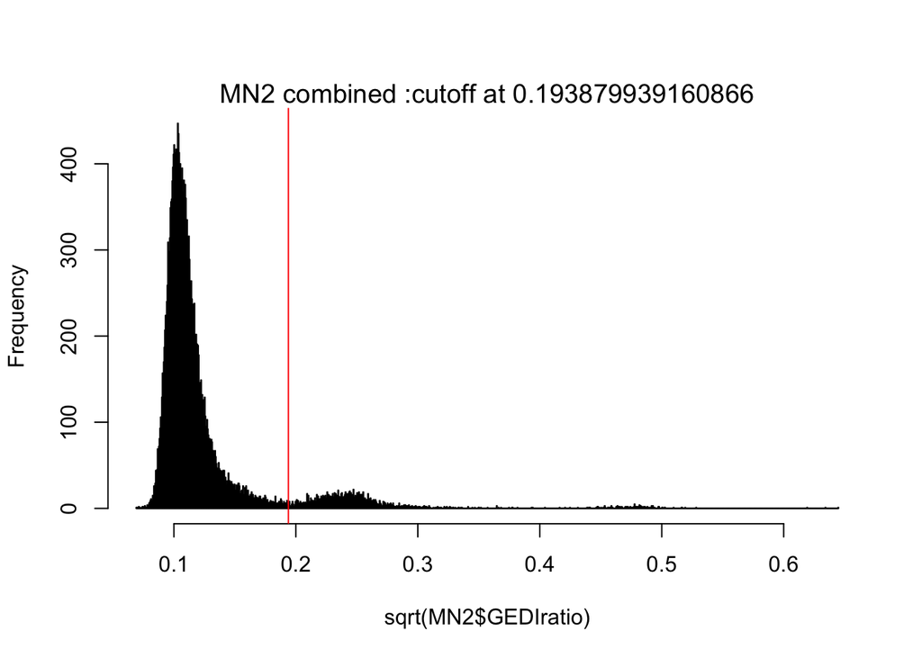

```r
### Use Rosner’s test to find outliers with the given number of estimated number of outliers. Take a square root of the raw value to make the distribution
# of live cells close to normal distribution

test <- rosnerTest(sqrt(MN2$GEDIratio),
                   k = outlierC)

### Find the smallest GEDI value of outlier cells
  outliers=test$all.stats$Value[test$all.stats$Outlier]
  cutoff=min( outliers[which(outliers>median(sqrt(MN2$GEDIratio)))] )

abline(v=cutoff,col="red")
mtext(paste0("MN2 combined :cutoff at ",cutoff),cex=1.2)
```

##### MN2 GEDI ratio distribution and estimated dead cell cutoff per time point

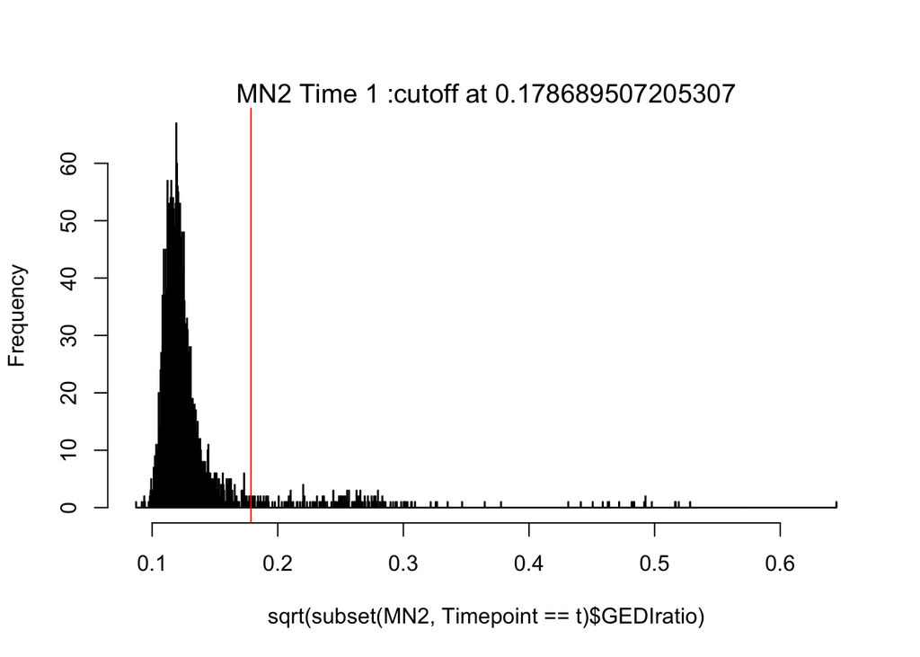

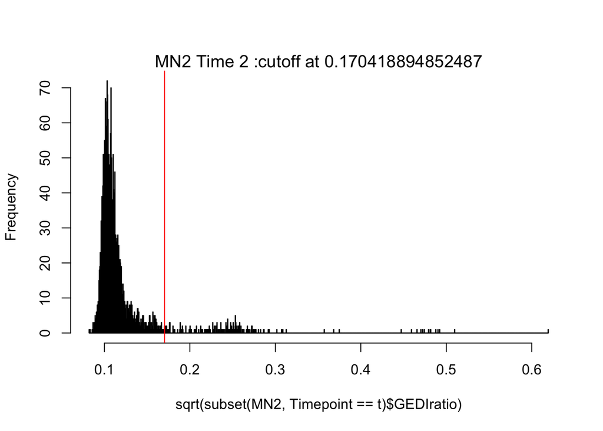

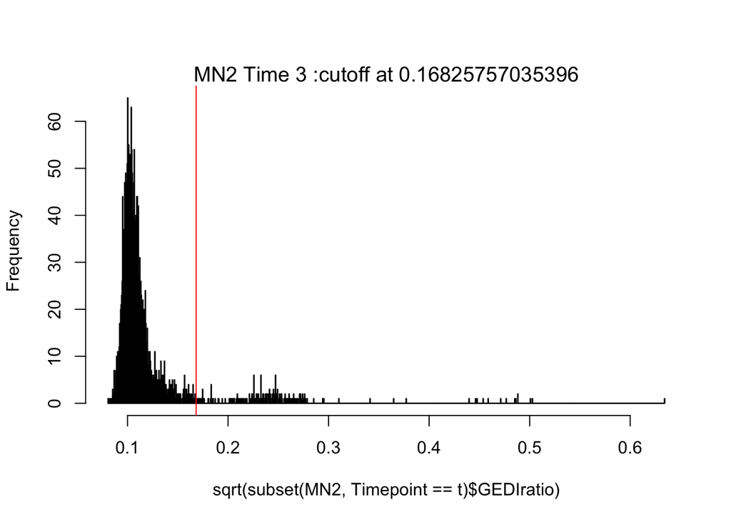

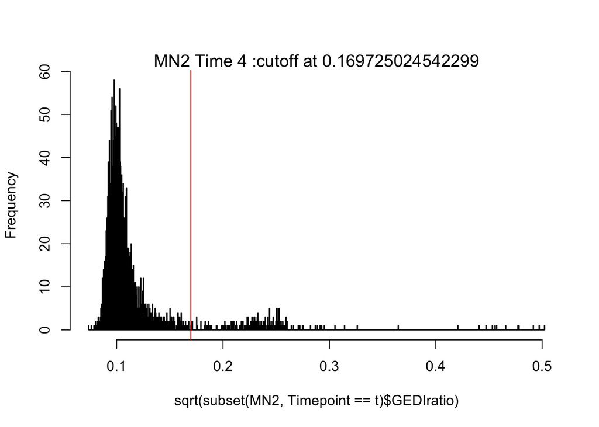

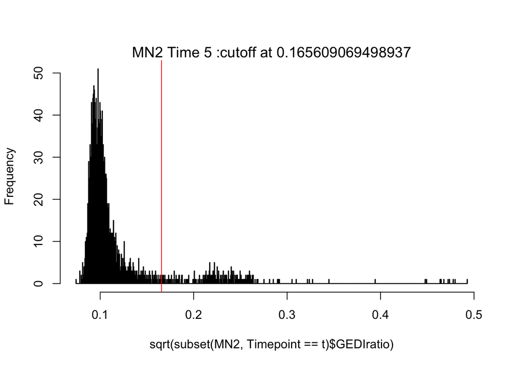

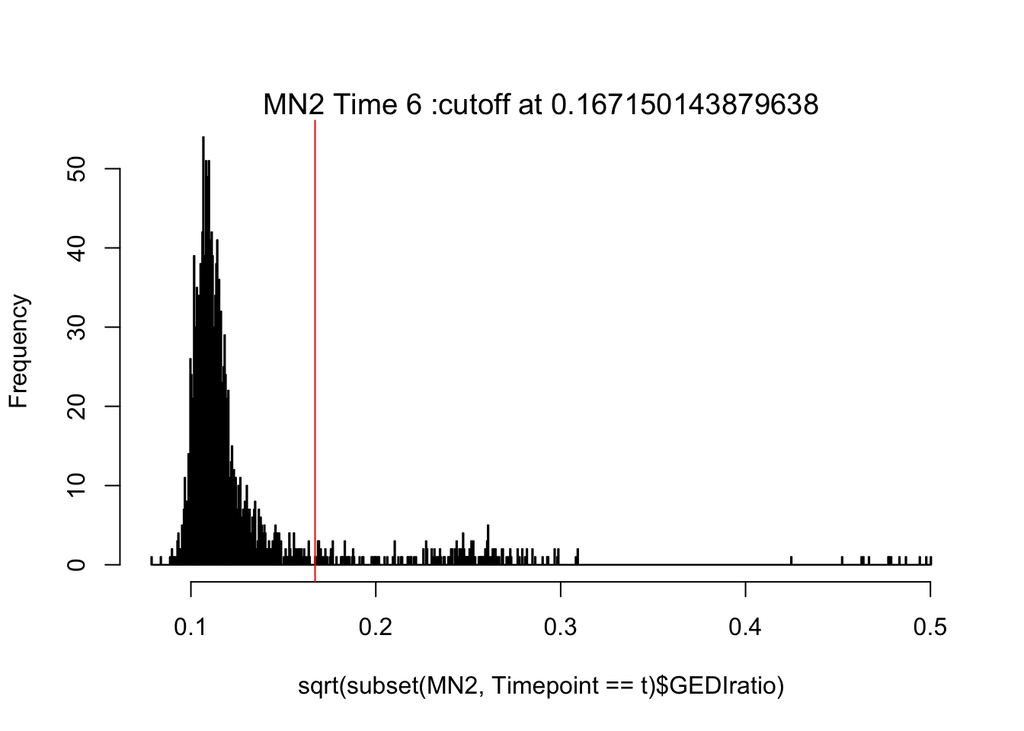

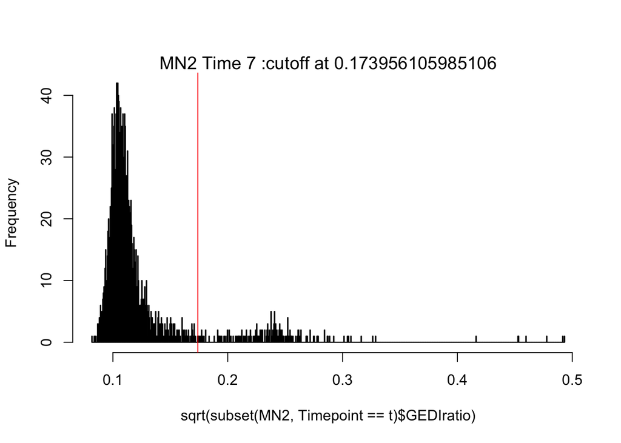

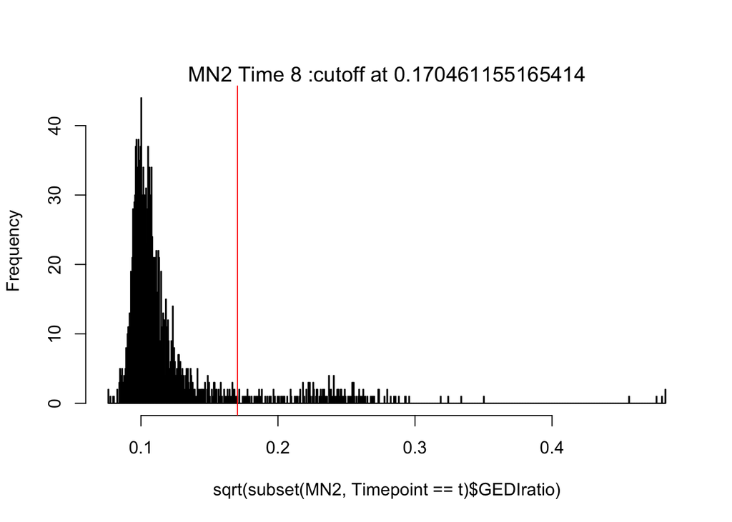

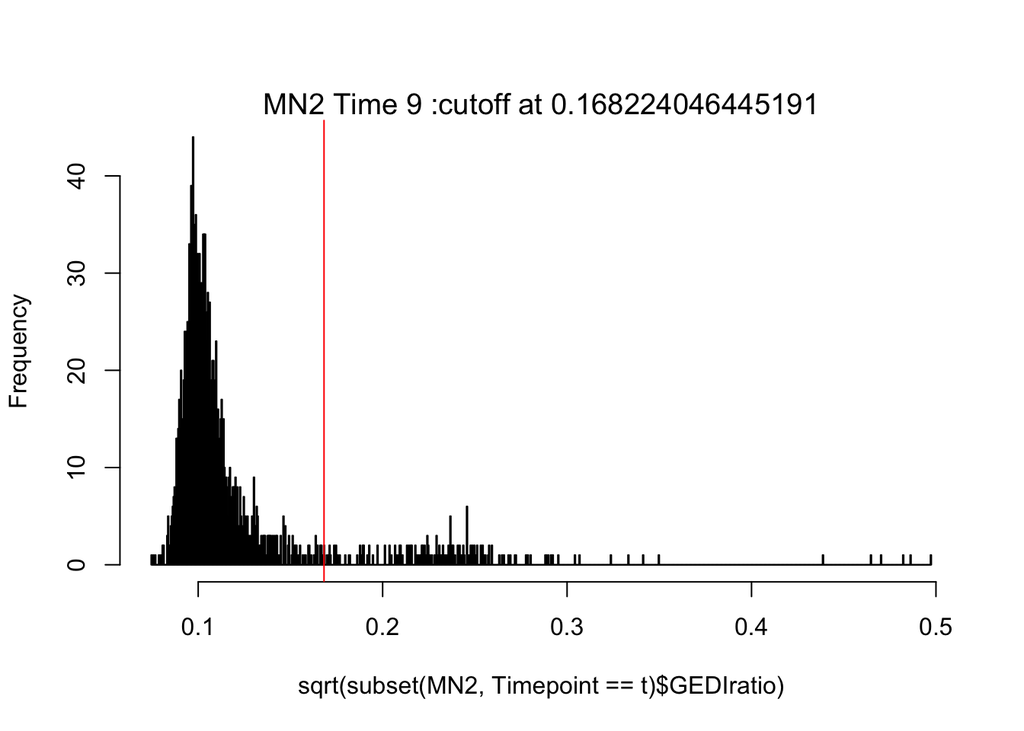

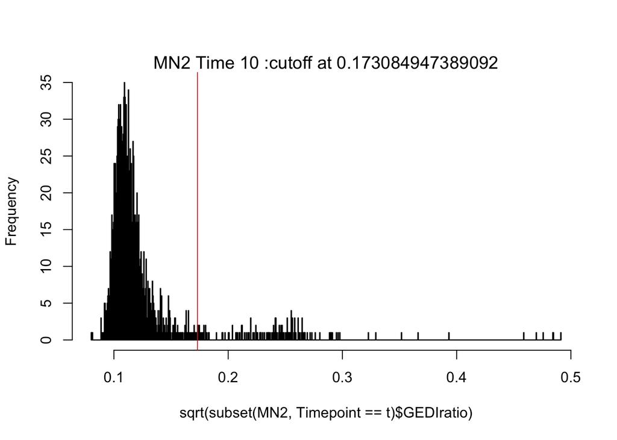

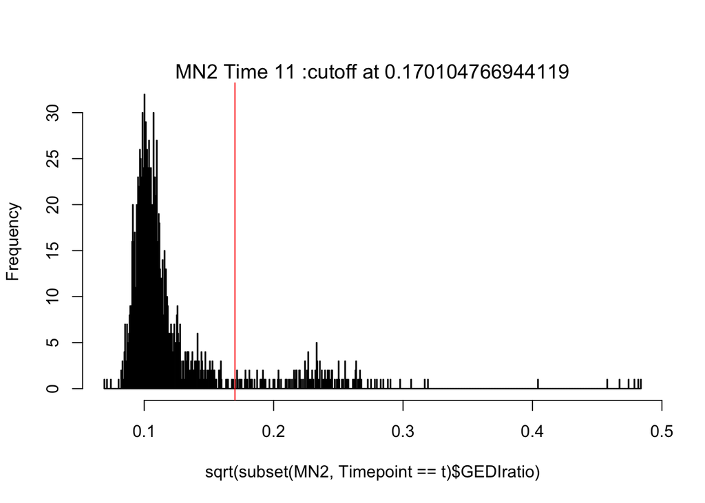

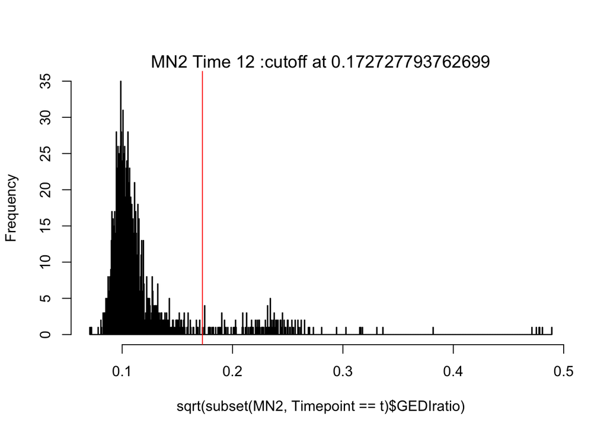

[1 more figures not shown]

```r
for(t in 1:max(as.numeric(MN2$Timepoint))){
  options(warn=-1)
  par(new=FALSE)

  upper_bound <- median(sqrt(subset(MN2,Timepoint==t)$GEDIratio)) + 3 * mad(sqrt(subset(MN2,Timepoint==t)$GEDIratio))
  upper_bound

  hist(sqrt(subset(MN2,Timepoint==t)$GEDIratio),breaks=1000,main=NULL)
 # abline(v=upper_bound, col="blue")

  outlierC=sum(sqrt(subset(MN2,Timepoint==t)$GEDIratio)>upper_bound)
  outlierC


  test <- rosnerTest(sqrt(subset(MN2,Timepoint==t)$GEDIratio),
                     k = outlierC)
  outliers=test$all.stats$Value[test$all.stats$Outlier]
  cutoff=min( outliers[which(outliers>median(sqrt(subset(MN2,Timepoint==t)$GEDIratio)))] )

  abline(v=cutoff,col="red")
  mtext(paste0("MN2 Time ",t," :cutoff at ",cutoff),cex=1.2)

}
```